# Is culture analysable?

Social and Cultural Analytics (7AAVBCS5)

Dr Mark J. Hill · mark.j.hill@kcl.ac.uk

2026-09-28

## Lecture Plan

**Part I: What is Social and Cultural Analytics?**

- What is culture?
- What is datafied culture?
- Cultural analytics and big data

**Part II: Introduction to Python**

- Introduction to Python and Positron
- Python as a calculator
- Variables in Python

**Goals**

First, convince you of the value of the module.

Second, set the substantive scene and encourage questions around social and cultural analytics such as:

- What does it mean to study culture?
- What types of culture can be studied?
- How do you, or can you, study it?

Third, introduce you to Python and Positron with some very basic coding.

# What is Culture? Foundational Definitions

## What is culture?

> ‘Culture … is that complex whole which includes knowledge, belief, art, morals, law, custom, and any other capabilities and habits acquired by man as a member of society.’ (Edward Burnett Tylor, *Primitive Culture* 1870)

> ‘Culture consists of patterns, explicit and implicit, of and for behaviour acquired and transmitted by symbols, constituting the distinctive achievements of human groups, including their embodiment in artifacts; the essential core of culture consists of traditional (i.e. historically derived and selected) ideas and especially their attached values; culture systems may, on the one hand, be considered as products of action, on the other, as conditional elements of future action.’ (Kroeber, A.L., & Kluckhohn, C. “Culture: A critical review of concepts and definitions.” 1952)

> ‘Culture is a fuzzy set of basic assumptions and values, orientations to life, beliefs, policies, procedures and behavioural conventions that are shared by a group of people, and that influence (but do not determine) each member’s behaviour and his/her interpretations of the ’meaning’ of other people’s behaviour.’ (Spencer-Oatey, *Culturally Speaking* 2008)

## What is culture? Complex and multifaceted

> ‘Culture … is that **complex whole** which includes **knowledge, belief, art, morals, law, custom, and any other capabilities and habits** acquired by man as a member of society.’ (Edward Burnett Tylor, *Primitive Culture* 1870)

> ‘Culture consists of **patterns, explicit and implicit**, of and for behaviour acquired and transmitted by symbols, constituting the distinctive achievements of human groups, **including their embodiment in artifacts**; the essential core of culture consists of traditional (i.e. historically derived and selected) ideas and especially their attached values; **culture systems may, on the one hand, be considered as products of action, on the other, as conditional elements of future action.**’ (Kroeber & Kluckhohn 1952)

> ‘Culture is a **fuzzy set** of basic assumptions and values, orientations to life, beliefs, policies, procedures and behavioural conventions that are shared by a group of people, and that influence (but do not determine) each member’s behaviour and his/her interpretations of the ’meaning’ of other people’s behaviour.’ (Spencer-Oatey 2008)

## What is culture? Learned and transmitted

> ‘Culture … is that complex whole which includes knowledge, belief, art, morals, law, custom, and any other capabilities and habits **acquired by man as a member of society**.’ (Edward Burnett Tylor, *Primitive Culture* 1870)

> ‘Culture consists of patterns, explicit and implicit, of and for behaviour **acquired and transmitted by symbols**, constituting the distinctive achievements of human groups, including their embodiment in artifacts; the essential core of culture consists of **traditional (i.e. historically derived and selected) ideas** and especially their attached values; culture systems may, on the one hand, be considered as products of action, on the other, as conditional elements of future action.’ (Kroeber & Kluckhohn 1952)

> ‘Culture is a fuzzy set of basic assumptions and values, orientations to life, beliefs, policies, procedures and behavioural conventions that are shared by a group of people, and that influence (but do not determine) each member’s behaviour and his/her interpretations of the ’meaning’ of other people’s behaviour.’ (Spencer-Oatey 2008)

## What is culture? Social and shared

> ‘Culture … is that complex whole which includes knowledge, belief, art, morals, law, custom, and any other capabilities and habits acquired by man **as a member of society**.’ (Edward Burnett Tylor, *Primitive Culture* 1870)

> ‘Culture consists of patterns, explicit and implicit, of and for behaviour acquired and transmitted by symbols, constituting the distinctive achievements of **human groups**, including their embodiment in artifacts; the essential core of culture consists of traditional (i.e. historically derived and selected) ideas and especially their attached values; culture systems may, on the one hand, be considered as products of action, on the other, as conditional elements of future action.’ (Kroeber & Kluckhohn 1952)

> ‘Culture is a fuzzy set of basic assumptions and values, orientations to life, beliefs, policies, procedures and behavioural conventions that are **shared by a group of people**, and that influence (but do not determine) each member’s behaviour and his/her interpretations of the ’meaning’ of other people’s behaviour.’ (Spencer-Oatey 2008)

## What is culture? Influences behaviour and meaning

> ‘Culture … is that complex whole which includes knowledge, belief, art, morals, law, custom, and any other **capabilities and habits** acquired by man as a member of society.’ (Edward Burnett Tylor, *Primitive Culture* 1870)

> ‘Culture consists of patterns, explicit and implicit, **of and for behaviour** acquired and transmitted by symbols, constituting the distinctive achievements of human groups, including their embodiment in artifacts; the essential core of culture consists of traditional (i.e. historically derived and selected) ideas and **especially their attached values**; culture systems may, on the one hand, be considered as products of action, on the other, as **conditional elements of future action**.’ (Kroeber & Kluckhohn 1952)

> ‘Culture is a fuzzy set of basic assumptions and values, orientations to life, beliefs, policies, procedures and behavioural conventions that are shared by a group of people, and that **influence (but do not determine) each member’s behaviour and his/her interpretations of the ’meaning’ of other people’s behaviour**.’ (Spencer-Oatey 2008)

# Adding (big) data

How is datified culture different?

## How is datified culture different? Abundance

Social interactions, cultural trends, and personal preferences are being quantified and analysed. This quantification allows for a more empirical approach to understanding culture but also raises issues around the interpretation and use of cultural data. (See: Van Dijck 2014; Lupton 2016)

[figure not shown]

[figure not shown]

[figure not shown]

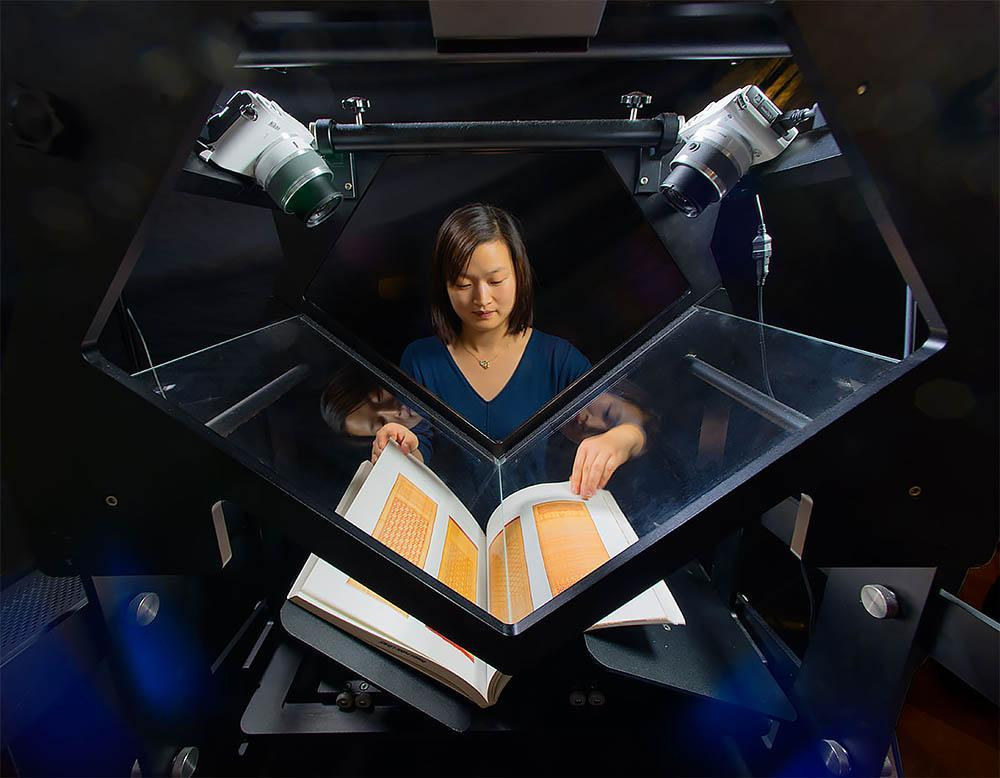

## How is datified culture different? Rapid, dynamic and evolving

Digital culture is characterised by its fast-paced evolution aided by the ease of information dissemination. This has led to quicker changes and adaptations in cultural trends and norms. (See: Castells 2010)

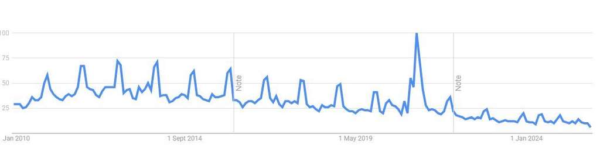

GameStop

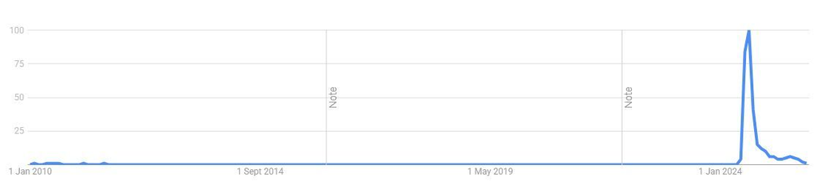

[figure not shown]

Brat summer

[figure not shown]

## How is datified culture different? Global and interconnective

The internet facilitates global interconnectivity which leads to unprecedented exchange of cultural ideas and practices (See: Appadurai 1996; Graham & Dutton 2019).

[figure not shown]

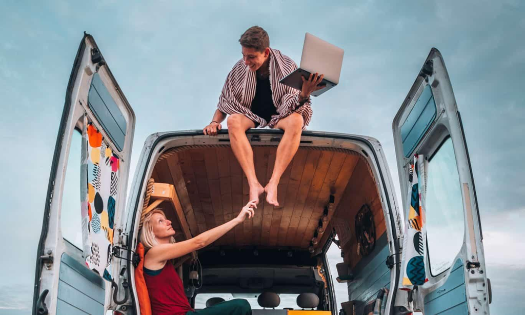

“Digital nomads”

## How is datified culture different? Alters perception of identity and community

Digital culture allows for the formation of communities and identities that are not constrained by geographical boundaries while also allowing people to look at their own (geographic) communities in new ways. (See: Baym 2015)

[figure not shown]

[figure not shown]

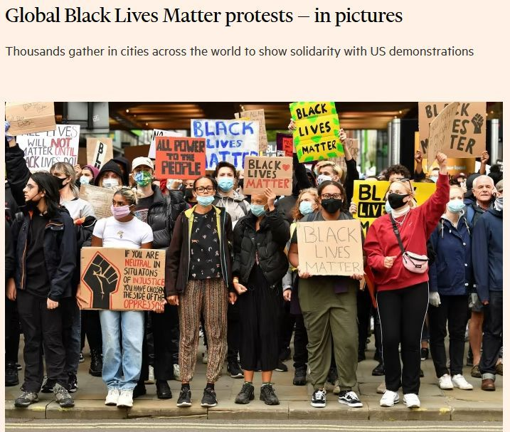

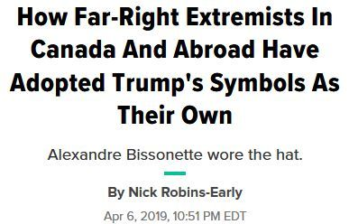

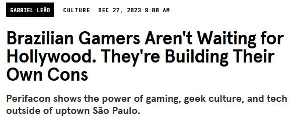

[figure not shown]

## How is datified culture different? Blurring of public and private spheres

Digital platforms have created spaces where personal experiences are shared widely and publicly, altering what can be considered public and private. (See: Marwick & boyd 2010)

[figure not shown]

Home assistants

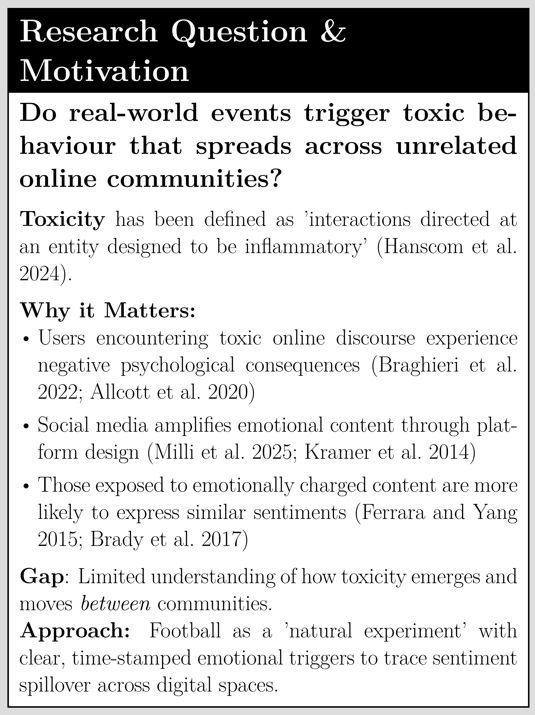

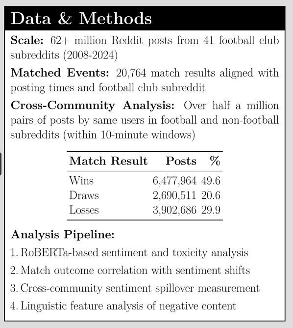

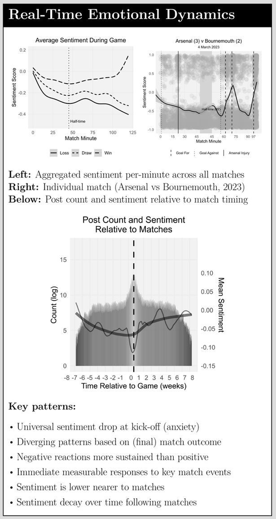

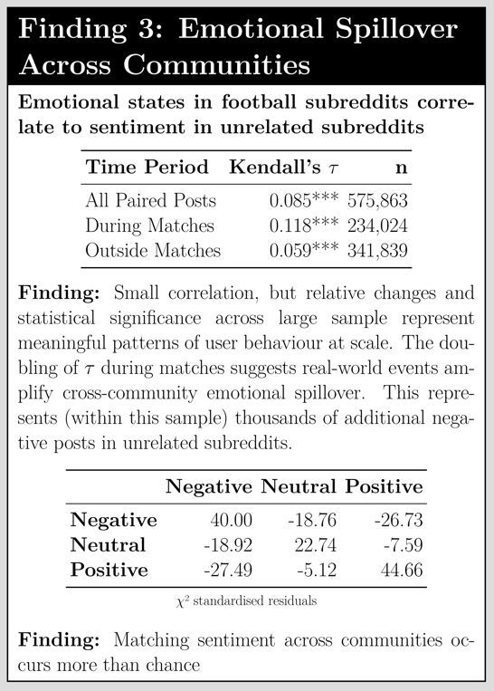

# From Cultural Analytics to Big Data and Society

## The promise of cultural computation

> “At its core, this big data revolution is about how humans create and preserve a historical record of their activities. Its consequences will transform how we look at ourselves. It will enable the creation of new scopes that make it possible for our society to more effectively probe its own nature. Big data is going to change the humanities, transform the social sciences, and renegotiate the relationship between the world of commerce and the ivory tower.”

> (Erez Aiden and Jean-Baptiste Michel, *Uncharted: Big Data as a Lens on Human Culture* 2013)

[figure not shown]

## The promise of data

> “This is a world where massive amounts of data and applied mathematics replace every other tool that might be brought to bear. Out with every theory of human behavior, from linguistics to sociology. Forget taxonomy, ontology, and psychology. Who knows why people do what they do? The point is they do it, and we can track and measure it with unprecedented fidelity. With enough data, the numbers speak for themselves.”

> (Chris Anderson, *Wired* 16.07)

[figure not shown]

[figure not shown]

[figure not shown]

## Traditional methods fail for datified/digital culture

> “Rather than drawing on digital data to revitalize [social sciences’] practices, they [social scientists] are still trying to pass them off as new terrains for old methods. Cyberculture, virtual communities, online identities, computer-mediated communication: all these notions have been developed to **quarantine the novelty of electronic media**… It is no longer possible to circumscribe digital interactions to a specific sector, as their threads are now ubiquitous woven into the fabric of collective existence. Digital media offer much more than just another field to apply existing methods: they offer the possibility of **restructuring the study of social existence**.”

> Tommaso Venturini and Bruno Latour, *The Social Fabric: Digital Traces and Quali-quantitative Methods* 2010

## Cultural Analytics

> “Cultural analytics relies on the computer and search algorithms in order to discern and interpret culture.” This is done through “the exploration of large cultural data sets by means of interactive and intuitive visual analysis techniques”

> (Lev Manovich, *Cultural Analytics* 2009)

> “[W]e are interested in combining both in the studies of cultures — focus on the particular, interpretation, and the past from the humanities and the focus on the general, formal models, and predicting the future from the sciences.”

> (Lev Manovich, “The Science of Culture? Social Computing, Digital Humanities and Cultural Analytics” 2016)

[figure not shown]

# So what can we actually analyse?

## Meaning is contextually constituted

A cultural object does not carry its meaning inside itself.

- The same word means different things in different decades
- The same map means different things to a tourist and a resident
- The same book means different things on a syllabus and in a market

Hill, “Contextual Analytics: Reconstructing Meaning in Computational Cultural Analysis”, §2.1

## What can computation operate on?

Computation needs a **discrete unit** — something countable, comparable, sortable.

Look back at the cat photograph and its metadata panel. The photograph is the cultural object. The panel — filename, date, camera, GPS — is what a computer can actually count and sort.

Turning a cultural object into such a unit is a **choice**, and the choice determines what you can subsequently see.

## Five dimensions of context

| Dimension | Unit of analysis | Native operations |
| --- | --- | --- |
| **Semiotic** | the sign | frequency, co-occurrence, distributional similarity |
| **Temporal** | the timestamp | sequencing, periodisation, rate of change |
| **Spatial** | the coordinate | mapping, clustering, distance, centre–periphery |
| **Social** | the agent attribute | grouping, comparison across populations |
| **Relational** | the edge | centrality, paths, community detection |

Hill, “Contextual Analytics”, §3 and Table 1

## The claim is not the pattern

A method detects a **pattern**. A cultural claim needs a **second dimension** to interpret it.

Look again at the poster:

- **semiotic** — Reddit posts
- **social** — club communities
- **relational** — spillover between communities
- **temporal** — match times, 2008–2024

The finding is a *correlation of sentiment across communities*.

Note what the poster does **not** claim: that football causes toxicity.

Every week: *what did the method detect, and what am I adding when I interpret it?*

## Which is also how you will write it up

| Stage | Question |
| --- | --- |
| 1. Object and claim | What am I studying, and what do I want to say about it? |
| 2. Dataset and boundaries | What entered the data, what did not, and why? |
| 3. Representing dimensions | What did I turn into a variable, and what did that discard? |
| 4. Designing for interaction | Which dimensions does my claim actually depend on? |
| 5. Interpretation and limits | What did I show, and what remains plausible but untested? |

Hill, “Contextual Analytics”, §5 — and the structure of your 3,500-word commentary

# Module details

## Background Survey

**Programming**

- No experience 47%
- Basic experience 53%

Languages used: R (35%), Python (24%), Other (59%)

**Disciplines**

- Media & Communications
- Digital Media
- Humanities (Literature, Philosophy, Art History)
- International Relations
- Business & Marketing

**Statistics & Analysis**

- Beginner level 94%
- Used summary statistics 59%
- Used hypothesis testing 41%
- Used visualisation 41%

**Career Plans**

- Industry 76%
- PhD 29%
- Public/Charity sector 24%
- Undecided 18%

## Module plan

**Lectures**

- Each week the lecture introduces a key topic/concept from both a theoretical and practical perspective
- Following this introductory lecture, there will be live coding examples illustrating the topic in practice.
- There will be **weekly quizzes on KEATS, sat in class, which count for 40% of your final mark**.

**Seminars**

- Seminars are guided by weekly exercises that allow you to put the previous lectures topics into practice.
- You can do the exercises before the seminar, and answers will be released at the end of the week.
- Seminar time should be seen as a time to ask questions you may have regarding both lectures and exercises.

## And weekly quizzes on KEATS!

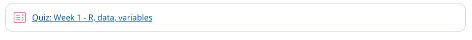

40% of your final mark

Sat in class, **nine times**, each covering the previous week.

Week 1’s quiz is **practice only** and does not count.

## The quiz schedule

| Week | Quiz covers | Week | Quiz covers |
| --- | --- | --- | --- |
| 1 | *practice — does not count* | 7 | Week 5 |
| 2 | Week 1 | 8 | Week 7 |
| 3 | Week 2 | 9 | Week 8 |
| 4 | Week 3 | 10 | Week 9 |
| 5 | Week 4 | 11 | Week 10 |
| 6 | *reading week* |  |  |

Multiple choice, plus short pieces of code you write and run.

The other **60%** is a data analysis and commentary — 3,500 words including code (±15%) — due **21 January 2027**.

# What is Python?

## What is Python?

**A General-Purpose Programming Language, Widely Used for Data Analysis**

Key Features:

- Interactive interface language — type commands, see immediate results
- Open-source and completely free — no licensing costs, ever
- Extensive community support — thousands of contributors worldwide
- Constantly evolving — new analytical methods added regularly

**Why Python for PGT Students?**

- Incredibly useful for thesis and dissertation analysis
- Enables reproducible research (share and re-run analyses)
- Highly valued in academia and industry
- Performs complex analyses impossible in spreadsheet software
- Unlike commercial software, accessible to all researchers globally

## Positron: An Integrated Development Environment (IDE)

**The Problem with Python on its own:**

- Default Python interface is command-line only
- Difficult to navigate and manage files
- Limited visual feedback

**The Positron Solution:**

- Professional interface with organised panes
- Editor for writing and saving code, as scripts or notebooks
- Console for executing commands
- Variables pane showing your data and variables
- Integrated file browser, plot viewer, and help system

Python is the engine, Positron is the interface

Positron is made by Posit, the same company that makes RStudio, so if you have seen RStudio the layout will look familiar.

## Installation

**Step 1: Install Python** (3.12 or 3.13) from https://www.python.org/downloads/

- **Windows** — tick **“Add python.exe to PATH”** on the first screen. It is off by default
- **Mac** — the universal2 installer. Not the Python already on your Mac
- **Linux** — `python3.12` and `python3.12-venv` from your package manager

**Step 2: Install Positron** from https://positron.posit.co/

- **Windows** `.exe` · **Mac** `.dmg` (Apple silicon or Intel) · **Linux** `.deb` / `.rpm`

**Step 3: Download `7AAVBCS5-setup.zip`** from KEATS and unzip it somewhere sensible

**Step 4: Create the environment in Positron**

- **File → Open Folder** → choose the folder (the *whole* folder, not one file)
- **Ctrl+Shift+P** → **Python: Create Environment** → **Venv** → your Python
- Tick **`requirements.txt`** when offered, and wait

Only once, in Week 1 — the same environment covers all eleven weeks. Full instructions, including a two-command terminal version, are on KEATS.

## Using Positron: The panes

**Editor**: write code here, in scripts or notebooks

**Console**: can type a single line of code here, but also where code executes, shows outputs and errors

**Variables**: overview of variables currently in memory, and their values

**Files/plots/help**: browse files, see visualisations you’ve created, output for documentation

## Python as a Calculator

- Open Positron
- Find the Console pane
- Type: `2+3`
- Press Enter
- Result: `5`

```python
2 + 3
```

```
5
```

**What happened?** You gave Python a command, Python executed it, Python returned the result.

**Important:** Python respects mathematical order of operations (PEMDAS/BODMAS)

## Operation Symbols

| Symbol | Operation | Example | Result |
| --- | --- | --- | --- |
| `+` | Addition | `5 + 3` | 8 |
| `-` | Subtraction | `10 - 4` | 6 |
| `*` | Multiplication | `7 * 8` | 56 |
| `/` | Division | `100 / 5` | 20.0 |
| `**` | Exponential | `2 ** 3` | 8 |

**Additional Useful Operators:**

`%` = Modulo (remainder): `10 % 3` gives 1

`//` = Integer division: `10 // 3` gives 3

**Built-in Functions:**

`abs()` = absolute value

`round()` = rounding

`math.sqrt()` = square root

`math.log()` = natural logarithm

`math.pi` = built-in constant π

## Variables

- A labeled storage/memory location for information
- Allows you to save and reuse results
- Foundation of all programming

You assign variables with `=`

**Naming rules and best practices:**

- Must start with a letter (or an underscore)
- Can contain letters, numbers, underscores (`_`)
- Case-sensitive: `MyVar != myvar != MYVAR`
- No spaces
- Cannot use reserved words: `True`, `False`, `None`, `if`, `else`, `for`, `class`
- Use descriptive names: `student_age` not `x`
- Use `snake_case` (`my_variable_name`) — the Python convention

## Variable Assignment Practice

```python
temperature_c = 20
temperature_f = temperature_c * 9 / 5 + 32
temperature_f
```

```
68.0
```

- Build complex analyses step-by-step
- Reuse values without recalculating
- Make code readable and self-documenting
- Variables appear in the **Variables** pane

## Data Types in Python: The Four Basic Types

**1. `float`** — For numbers with decimals

**2. `int`** — For whole numbers

- Uses less memory than float

N.B.: Rarely need to specify explicitly between int and float. Python decides for you, and converts when it needs to.

**3. `str` (String)** — For text

- Must use quotes (single or double)

**4. `bool` (Boolean)** — `True` or `False`

- Used for conditions and filtering
- Must be **capitalised**, no quotes
- Cannot be abbreviated to `T` / `F`

```python
print(type(7), type(7.5), type("London"), type(True))
```

```
<class 'int'> <class 'float'> <class 'str'> <class 'bool'>
```

## Data Types in Python: Checking and Converting Types

Data types can be converted using the following functions:

```python
print(int("42"), type(int("42")))
print(float("3.14"), type(float("3.14")))
print(str(42), type(str(42)))
print(bool(0), bool(1))
```

```
42 <class 'int'>
3.14 <class 'float'>
42 <class 'str'>
False True
```

Check a type with `type()`:

```python
answer = 42
type(answer)
```

```
int
```

## Best Practices and Getting Help

**Use Consistent Style:**

- Pick naming convention and stick to it
- **Indentation is part of Python’s syntax** — four spaces inside functions and loops, and it is not optional
- Add blank lines between logical sections
- Makes code easier to read and debug

**Comment Your Code:**

- Explain WHY, not just WHAT
- Good: `# Convert temperature for US audience`
- Less useful: `# Multiply by 9/5 and add 32`
- Future-you will thank present-you

**Test as You Go:**

- Run code chunk-by-chunk
- Don’t write 100 lines then hope it works
- Fix errors immediately when they appear

**Before Seeking Help:**

- Check for typos (most common error!)
- Read the error message carefully
- Try Google with exact error message
- Create minimal example that reproduces problem

## And ask me questions!

I’m certain you will ask me things I don’t know the answer to. When that happens, I’ll look up the answer. In coding — especially starting out — there are no stupid questions (honestly) — even professional coders Google constantly.

## That’s it! Thanks!

Questions?